# MARK-2.1

## TOPIC:

Predictive Analysis of Crimes Against Women Using Machine Learning

## PROBLEM STATEMENT:

This project aims to analyze crimes against women in India using historical crime data, focusing on identifying trends, understanding correlations among different types of crimes, and predicting future crime patterns. The ultimate goal is to provide actionable insights that can guide public safety policies, resource allocation, and community awareness programs to mitigate crimes against women.

## USE CASE:

If this model is combined with additional data sources, such as socio-economic factors (e.g., education levels, unemployment rates, and income inequality) or demographic data (e.g., population density and gender ratio), it could provide deeper insights into the root causes of crimes against women. This integration would enhance the model's predictive capabilities and support the development of more targeted and impactful policies and interventions.

## I. Importing essential libraries

```python
import pandas as pd
import numpy as np
import matplotlib.pyplot as plt
import seaborn as sns
```

## II. Importing and understanding our dataset

```python
data = pd.read_csv("C:/Users/Admin/Desktop/project/CrimesOnWomenData.csv")
```

```python
data
```

|  | Column1 | State | Year | Rape | K&A | DD | AoW | AoM | DV | WT | Unnamed: 10 | Unnamed: 11 | Unnamed: 12 | Unnamed: 13 |
| --- | --- | --- | --- | --- | --- | --- | --- | --- | --- | --- | --- | --- | --- | --- |
| 0 | 0 | ANDHRA PRADESH | 2001 | 871 | 765 | 420 | 3544 | 2271 | 5791 | 7 | NaN | NaN | NaN | NaN |
| 1 | 1 | ARUNACHAL PRADESH | 2001 | 33 | 55 | 0 | 78 | 3 | 11 | 0 | NaN | NaN | NaN | NaN |
| 2 | 2 | ASSAM | 2001 | 817 | 1070 | 59 | 850 | 4 | 1248 | 0 | NaN | NaN | NaN | NaN |
| 3 | 3 | BIHAR | 2001 | 888 | 518 | 859 | 562 | 21 | 1558 | 83 | NaN | NaN | Rape | No. of Rape cases |
| 4 | 4 | CHHATTISGARH | 2001 | 959 | 171 | 70 | 1763 | 161 | 840 | 0 | NaN | NaN | K&A | Kidnap And Assault |
| ... | ... | ... | ... | ... | ... | ... | ... | ... | ... | ... | ... | ... | ... | ... |
| 731 | 731 | D&N Haveli | 2021 | 1250 | 4083 | 141 | 2068 | 417 | 4731 | 4 | NaN | NaN | NaN | NaN |
| 732 | 732 | Daman & Diu | 2021 | 315 | 904 | 16 | 1851 | 10 | 501 | 1 | NaN | NaN | NaN | NaN |
| 733 | 733 | Delhi UT | 2021 | 2 | 1 | 0 | 5 | 1 | 9 | 0 | NaN | NaN | NaN | NaN |
| 734 | 734 | Lakshadweep | 2021 | 0 | 0 | 0 | 1 | 1 | 3 | 0 | NaN | NaN | NaN | NaN |
| 735 | 735 | Puducherry | 2021 | 2 | 0 | 2 | 31 | 3 | 12 | 0 | NaN | NaN | NaN | NaN |

736 rows × 14 columns

```python
data.shape
```

```
(736, 14)
```

```python
data.isna().sum()
```

```
Column1          0
State            0
Year             0
Rape             0
K&A              0
DD               0
AoW              0
AoM              0
DV               0
WT               0
Unnamed: 10    736
Unnamed: 11    736
Unnamed: 12    729
Unnamed: 13    729
dtype: int64
```

```python
# we have missing values
```

```python
data.info()
```

```
<class 'pandas.core.frame.DataFrame'>
RangeIndex: 736 entries, 0 to 735
Data columns (total 14 columns):
 #   Column       Non-Null Count  Dtype
---  ------       --------------  -----
 0   Column1      736 non-null    int64
 1   State        736 non-null    object
 2   Year         736 non-null    int64
 3   Rape         736 non-null    int64
 4   K&A          736 non-null    int64
 5   DD           736 non-null    int64
 6   AoW          736 non-null    int64
 7   AoM          736 non-null    int64
 8   DV           736 non-null    int64
 9   WT           736 non-null    int64
 10  Unnamed: 10  0 non-null      float64
 11  Unnamed: 11  0 non-null      float64
 12  Unnamed: 12  7 non-null      object
 13  Unnamed: 13  7 non-null      object
dtypes: float64(2), int64(9), object(3)
memory usage: 80.6+ KB
```

```python
data["Unnamed: 10"].value_counts
```

```
<bound method IndexOpsMixin.value_counts of 0     NaN
1     NaN
2     NaN
3     NaN
4     NaN
       ..
731   NaN
732   NaN
733   NaN
734   NaN
735   NaN
Name: Unnamed: 10, Length: 736, dtype: float64>
```

```python
data["Unnamed: 11"].value_counts
```

```
<bound method IndexOpsMixin.value_counts of 0     NaN
1     NaN
2     NaN
3     NaN
4     NaN
       ..
731   NaN
732   NaN
733   NaN
734   NaN
735   NaN
Name: Unnamed: 11, Length: 736, dtype: float64>
```

```python
data["Unnamed: 12"].value_counts
```

```
<bound method IndexOpsMixin.value_counts of 0       NaN
1       NaN
2       NaN
3      Rape
4       K&A
       ...
731     NaN
732     NaN
733     NaN
734     NaN
735     NaN
Name: Unnamed: 12, Length: 736, dtype: object>
```

```python
data["Unnamed: 13"].value_counts
```

```
<bound method IndexOpsMixin.value_counts of 0                     NaN
1                     NaN
2                     NaN
3       No. of Rape cases
4      Kidnap And Assault
              ...
731                   NaN
732                   NaN
733                   NaN
734                   NaN
735                   NaN
Name: Unnamed: 13, Length: 736, dtype: object>
```

We will drop the unwanted columns (column1, unnamed: 10, unnamed: 11, unnamed: 12, unnamed: 13) from the dataset as they do not contribute any meaningful information to the analysis.

```python
data.drop("Unnamed: 10", axis=1, inplace=True)
```

```python
data.drop("Unnamed: 11", axis=1, inplace=True)
```

```python
data.drop("Unnamed: 12", axis=1, inplace=True)
```

```python
data.drop("Unnamed: 13", axis=1, inplace=True)
```

```python
data.drop("Column1", axis=1, inplace=True)
```

```python
data
```

|  | State | Year | Rape | K&A | DD | AoW | AoM | DV | WT |
| --- | --- | --- | --- | --- | --- | --- | --- | --- | --- |
| 0 | ANDHRA PRADESH | 2001 | 871 | 765 | 420 | 3544 | 2271 | 5791 | 7 |
| 1 | ARUNACHAL PRADESH | 2001 | 33 | 55 | 0 | 78 | 3 | 11 | 0 |
| 2 | ASSAM | 2001 | 817 | 1070 | 59 | 850 | 4 | 1248 | 0 |
| 3 | BIHAR | 2001 | 888 | 518 | 859 | 562 | 21 | 1558 | 83 |
| 4 | CHHATTISGARH | 2001 | 959 | 171 | 70 | 1763 | 161 | 840 | 0 |
| ... | ... | ... | ... | ... | ... | ... | ... | ... | ... |
| 731 | D&N Haveli | 2021 | 1250 | 4083 | 141 | 2068 | 417 | 4731 | 4 |
| 732 | Daman & Diu | 2021 | 315 | 904 | 16 | 1851 | 10 | 501 | 1 |
| 733 | Delhi UT | 2021 | 2 | 1 | 0 | 5 | 1 | 9 | 0 |
| 734 | Lakshadweep | 2021 | 0 | 0 | 0 | 1 | 1 | 3 | 0 |
| 735 | Puducherry | 2021 | 2 | 0 | 2 | 31 | 3 | 12 | 0 |

736 rows × 9 columns

```python
#checking the consistency of data
```

```python
data.Year.value_counts().sort_index()
```

```
Year
2001    34
2002    34
2003    34
2004    34
2005    34
2006    34
2007    34
2008    34
2009    34
2010    34
2011    36
2012    36
2013    36
2014    36
2015    36
2016    36
2017    36
2018    36
2019    36
2020    36
2021    36
Name: count, dtype: int64
```

```python
# Group by 'State' and aggregate the range of years for each state
state_year_range = data.groupby('State')['Year'].agg(['min', 'max']).reset_index()
#the above code identifies the earliest (min) and latest (max) years for each state.
```

```python
# Filter states based on the year range
states_2001_2010 = state_year_range[(state_year_range['min'] >= 2001) & (state_year_range['max'] <= 2010)]
states_2011_2021 = state_year_range[(state_year_range['min'] >= 2011) & (state_year_range['max'] <= 2021)]
'''
Filter for states where the minimum year is >= 2001 and maximum year is <= 2010 for the first group.
Similarly, filter for states where the minimum year is >= 2011 and maximum year is <= 2021 for the second group.
'''
```

```
'\nFilter for states where the minimum year is >= 2001 and maximum year is <= 2010 for the first group.\nSimilarly, filter for states where the minimum year is >= 2011 and maximum year is <= 2021 for the second group.\n'
```

```python
#Convert the resulting DataFrame of states into lists for easier readability.
states_2001_2010_list = states_2001_2010['State'].tolist()
states_2011_2021_list = states_2011_2021['State'].tolist()
```

```python
# Display results
print("States with records from 2001 to 2010:", states_2001_2010_list)
print("*" * 153)
print("States with records from 2011 to 2021:", states_2011_2021_list)
```

```
States with records from 2001 to 2010: ['A & N ISLANDS', 'ANDHRA PRADESH', 'ARUNACHAL PRADESH', 'ASSAM', 'BIHAR', 'CHANDIGARH', 'CHHATTISGARH', 'D & N HAVELI', 'DAMAN & DIU', 'GOA', 'GUJARAT', 'HARYANA', 'HIMACHAL PRADESH', 'JAMMU & KASHMIR', 'JHARKHAND', 'KARNATAKA', 'KERALA', 'LAKSHADWEEP', 'MADHY…
States with records from 2011 to 2021: ['A & N Islands', 'Andhra Pradesh', 'Arunachal Pradesh', 'Assam', 'Bihar', 'Chandigarh', 'Chhattisgarh', 'D&N Haveli', 'Daman & Diu', 'Delhi UT', 'Goa', 'Gujarat', 'Haryana', 'Himachal Pradesh', 'Jammu & Kashmir', 'Jharkhand', 'Karnataka', 'Kerala', 'Lakshadwee…
```

**States with records from 2011 to 2021**: Notably, new entries like *Delhi UT* and *Telangana* were added in this period. This inclusion highlights the evolution of administrative boundaries and data collection practices over time.

**Renaming the columns for better understanding**

```python
data.rename(columns={
    'K&A': 'Kidnap_&_Assault',
    'DD': 'Dowry_Death',
    'AoW': 'Assault_Against_Women',
    'AoM': 'Assault_Against_Modesty_Of_Women',
    'DV': 'Domestic_Violence',
    'WT': 'Women_Trafficking'
}, inplace=True)
```

```python
data
```

|  | State | Year | Rape | Kidnap_&_Assault | Dowry_Death | Assault_Against_Women | Assault_Against_Modesty_Of_Women | Domestic_Violence | Women_Trafficking |
| --- | --- | --- | --- | --- | --- | --- | --- | --- | --- |
| 0 | ANDHRA PRADESH | 2001 | 871 | 765 | 420 | 3544 | 2271 | 5791 | 7 |
| 1 | ARUNACHAL PRADESH | 2001 | 33 | 55 | 0 | 78 | 3 | 11 | 0 |
| 2 | ASSAM | 2001 | 817 | 1070 | 59 | 850 | 4 | 1248 | 0 |
| 3 | BIHAR | 2001 | 888 | 518 | 859 | 562 | 21 | 1558 | 83 |
| 4 | CHHATTISGARH | 2001 | 959 | 171 | 70 | 1763 | 161 | 840 | 0 |
| ... | ... | ... | ... | ... | ... | ... | ... | ... | ... |
| 731 | D&N Haveli | 2021 | 1250 | 4083 | 141 | 2068 | 417 | 4731 | 4 |
| 732 | Daman & Diu | 2021 | 315 | 904 | 16 | 1851 | 10 | 501 | 1 |
| 733 | Delhi UT | 2021 | 2 | 1 | 0 | 5 | 1 | 9 | 0 |
| 734 | Lakshadweep | 2021 | 0 | 0 | 0 | 1 | 1 | 3 | 0 |
| 735 | Puducherry | 2021 | 2 | 0 | 2 | 31 | 3 | 12 | 0 |

736 rows × 9 columns

**Creating target variable**

```python
data['Total_Crime']=data[['Kidnap_&_Assault','Dowry_Death','Assault_Against_Women',
                          'Assault_Against_Modesty_Of_Women','Domestic_Violence','Women_Trafficking']].sum(axis=1)
```

*The Total_Crime column now represents the aggregate of all specified crime categories for each record in the dataset.*

```python
data
```

|  | State | Year | Rape | Kidnap_&_Assault | Dowry_Death | Assault_Against_Women | Assault_Against_Modesty_Of_Women | Domestic_Violence | Women_Trafficking | Total_Crime |
| --- | --- | --- | --- | --- | --- | --- | --- | --- | --- | --- |
| 0 | ANDHRA PRADESH | 2001 | 871 | 765 | 420 | 3544 | 2271 | 5791 | 7 | 12798 |
| 1 | ARUNACHAL PRADESH | 2001 | 33 | 55 | 0 | 78 | 3 | 11 | 0 | 147 |
| 2 | ASSAM | 2001 | 817 | 1070 | 59 | 850 | 4 | 1248 | 0 | 3231 |
| 3 | BIHAR | 2001 | 888 | 518 | 859 | 562 | 21 | 1558 | 83 | 3601 |
| 4 | CHHATTISGARH | 2001 | 959 | 171 | 70 | 1763 | 161 | 840 | 0 | 3005 |
| ... | ... | ... | ... | ... | ... | ... | ... | ... | ... | ... |
| 731 | D&N Haveli | 2021 | 1250 | 4083 | 141 | 2068 | 417 | 4731 | 4 | 11444 |
| 732 | Daman & Diu | 2021 | 315 | 904 | 16 | 1851 | 10 | 501 | 1 | 3283 |
| 733 | Delhi UT | 2021 | 2 | 1 | 0 | 5 | 1 | 9 | 0 | 16 |
| 734 | Lakshadweep | 2021 | 0 | 0 | 0 | 1 | 1 | 3 | 0 | 5 |
| 735 | Puducherry | 2021 | 2 | 0 | 2 | 31 | 3 | 12 | 0 | 48 |

736 rows × 10 columns

## III. Checking for outliers

```python
dataobject=data.select_dtypes(include='object')
datanum=data.select_dtypes(exclude='object')
```

```python
dataobject
```

|  | State |
| --- | --- |
| 0 | ANDHRA PRADESH |
| 1 | ARUNACHAL PRADESH |
| 2 | ASSAM |
| 3 | BIHAR |
| 4 | CHHATTISGARH |
| ... | ... |
| 731 | D&N Haveli |
| 732 | Daman & Diu |
| 733 | Delhi UT |
| 734 | Lakshadweep |
| 735 | Puducherry |

736 rows × 1 columns

```python
datanum
```

|  | Year | Rape | Kidnap_&_Assault | Dowry_Death | Assault_Against_Women | Assault_Against_Modesty_Of_Women | Domestic_Violence | Women_Trafficking | Total_Crime |
| --- | --- | --- | --- | --- | --- | --- | --- | --- | --- |
| 0 | 2001 | 871 | 765 | 420 | 3544 | 2271 | 5791 | 7 | 12798 |
| 1 | 2001 | 33 | 55 | 0 | 78 | 3 | 11 | 0 | 147 |
| 2 | 2001 | 817 | 1070 | 59 | 850 | 4 | 1248 | 0 | 3231 |
| 3 | 2001 | 888 | 518 | 859 | 562 | 21 | 1558 | 83 | 3601 |
| 4 | 2001 | 959 | 171 | 70 | 1763 | 161 | 840 | 0 | 3005 |
| ... | ... | ... | ... | ... | ... | ... | ... | ... | ... |
| 731 | 2021 | 1250 | 4083 | 141 | 2068 | 417 | 4731 | 4 | 11444 |
| 732 | 2021 | 315 | 904 | 16 | 1851 | 10 | 501 | 1 | 3283 |
| 733 | 2021 | 2 | 1 | 0 | 5 | 1 | 9 | 0 | 16 |
| 734 | 2021 | 0 | 0 | 0 | 1 | 1 | 3 | 0 | 5 |
| 735 | 2021 | 2 | 0 | 2 | 31 | 3 | 12 | 0 | 48 |

736 rows × 9 columns

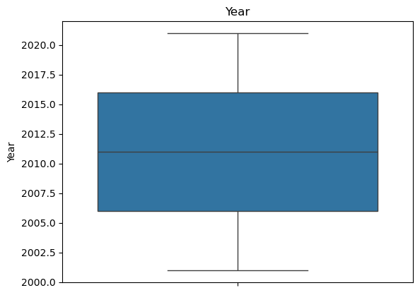

```
Q1:  2006.0
Q2:  2011.0
Q3:  2016.0
IQR:  10.0
UPPER TAIL:  2031.0
LOWER TAIL:  1991.0
```

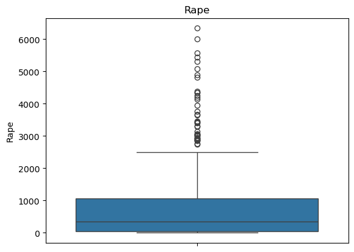

```
Q1:  35.0
Q2:  348.5
Q3:  1069.0
IQR:  1034.0
UPPER TAIL:  2620.0
LOWER TAIL:  -1516.0
```

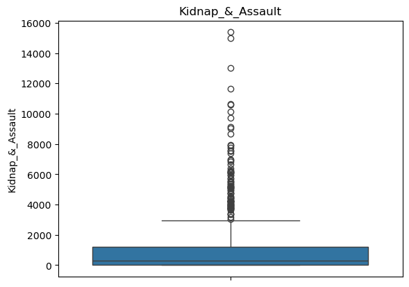

```
Q1:  24.75
Q2:  290.0
Q3:  1216.0
IQR:  1191.25
UPPER TAIL:  3002.875
LOWER TAIL:  -1762.125
```

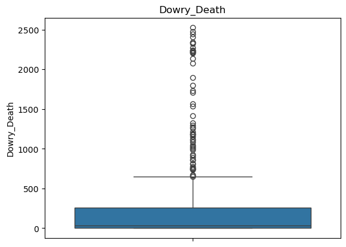

```
Q1:  1.0
Q2:  29.0
Q3:  259.0
IQR:  258.0
UPPER TAIL:  646.0
LOWER TAIL:  -386.0
```

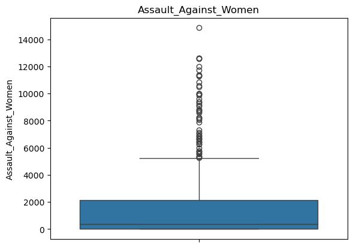

```
Q1:  34.0
Q2:  387.5
Q3:  2122.25
IQR:  2088.25
UPPER TAIL:  5254.625
LOWER TAIL:  -3098.375
```

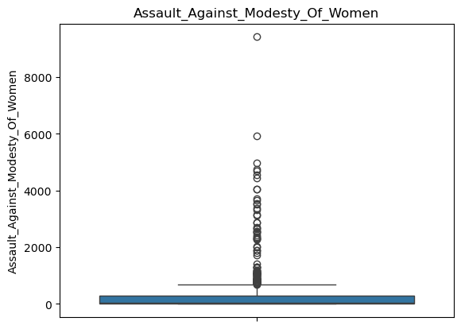

```
Q1:  3.0
Q2:  31.0
Q3:  277.5
IQR:  274.5
UPPER TAIL:  689.25
LOWER TAIL:  -408.75
```

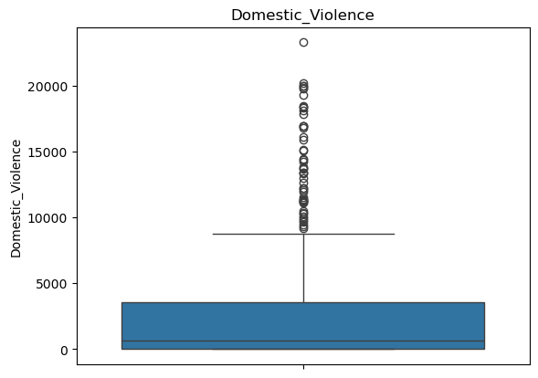

```
Q1:  13.0
Q2:  678.5
Q3:  3545.0
IQR:  3532.0
UPPER TAIL:  8843.0
LOWER TAIL:  -5285.0
```

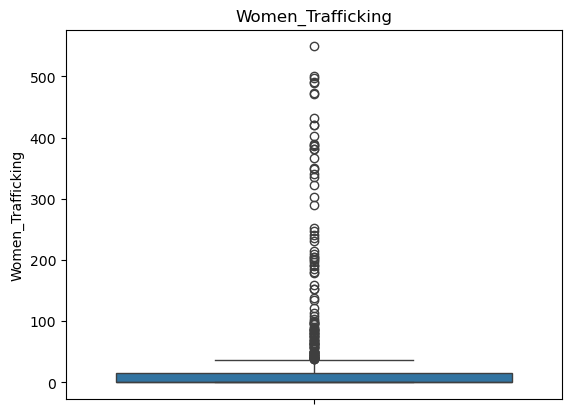

```
Q1:  0.0
Q2:  0.0
Q3:  15.0
IQR:  15.0
UPPER TAIL:  37.5
LOWER TAIL:  -22.5
```

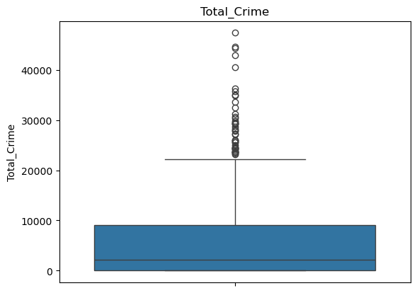

```
Q1:  101.0
Q2:  2149.5
Q3:  9067.75
IQR:  8966.75
UPPER TAIL:  22517.875
LOWER TAIL:  -13349.125
```

```python
for i in datanum.columns:
    sns.boxplot(data[i])
    plt.title(i)
    plt.show()
    q1=datanum[i].quantile(0.25)
    q2=datanum[i].quantile(0.50)
    q3=datanum[i].quantile(0.75)
    iqr=q3-q1
    upt=q3+1.5*iqr
    lwt=q1-1.5*iqr
    print("Q1: ",q1)
    print("Q2: ",q2)
    print("Q3: ",q3)
    print("IQR: ",iqr)
    print("UPPER TAIL: ",upt)
    print("LOWER TAIL: ",lwt)
```

```python
for i in datanum.columns:
    print(f"Value counts for column: {i}")
    print(datanum[i].value_counts())
    print("-" * 50)
```

```
Value counts for column: Year
Year
2011    36
2012    36
2020    36
2019    36
2018    36
2017    36
2016    36
2015    36
2014    36
2013    36
2021    36
2002    34
2010    34
2009    34
2008    34
2007    34
2006    34
2005    34
2004    34
2003    34
2001    34
Name: count, dtype: int64
--------------------------------------------------
Value counts for column: Rape
Rape
0       19
2       13
1       12
3       11
18       9
        ..
1871     1
204      1
573      1
1355     1
315      1
Name: count, Length: 498, dtype: int64
--------------------------------------------------
```

[output cut: 90 more lines]

```
Value counts for column: Total_Crime
Total_Crime
0        8
5        7
16       6
2        5
15       5
        ..
13927    1
11929    1
7338     1
5301     1
48       1
Name: count, Length: 602, dtype: int64
--------------------------------------------------
```

**The dataset used for this analysis, Crimes Against Women, is derived from an official government website, ensuring that the data is accurate, reliable, and reflective of real-world crime statistics.**

**Outlier detection was performed using statistical methods, including visualizations like boxplots and metrics such as the Interquartile Range (IQR). Data points lying beyond 1.5 times the IQR(upper tail and lower tail) were flagged as potential outliers.**

**Upon further inspection and considering the domain context, it was observed that the flagged data points represent regions or years with exceptionally high crime rates. These values are not errors or anomalies but rather significant data points capturing real trends, such as spikes in crimes during certain years or in specific regions.**

**As this dataset is sourced from a government platform, the flagged data points are verified and represent actual reported crimes. Thus, they are considered valid for the analysis despite being statistically identified as outliers.**

## IV. Checking correlation between columns

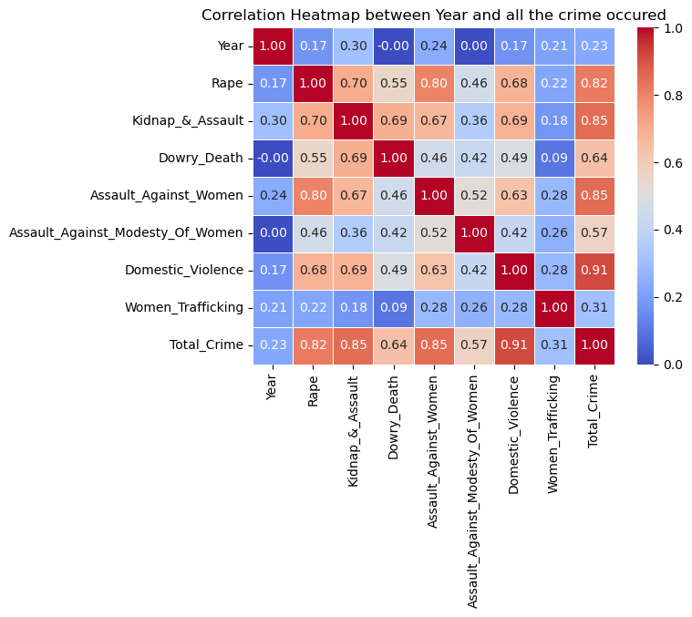

```python
sns.heatmap(datanum.corr(),annot=True,fmt=".2f",cmap="coolwarm",linewidths=0.5)
plt.title("Correlation Heatmap between Year and all the crime occured")
plt.show()
```

**The weak correlations between year and most crime types indicate that either crime rates have not changed much over time, or that any identifiable trends have been obscured by changes in reporting procedures (such as underreporting or better data collection in subsequent years).**

## V. Analyzing the skewness of the dataset

```
array([[<Axes: title={'center': 'Year'}>,
        <Axes: title={'center': 'Rape'}>,
        <Axes: title={'center': 'Kidnap_&_Assault'}>],
       [<Axes: title={'center': 'Dowry_Death'}>,
        <Axes: title={'center': 'Assault_Against_Women'}>,
        <Axes: title={'center': 'Assault_Against_Modesty_Of_Women'}>],
       [<Axes: title={'center': 'Domestic_Violence'}>,
        <Axes: title={'center': 'Women_Trafficking'}>,
        <Axes: title={'center': 'Total_Crime'}>]], dtype=object)
```

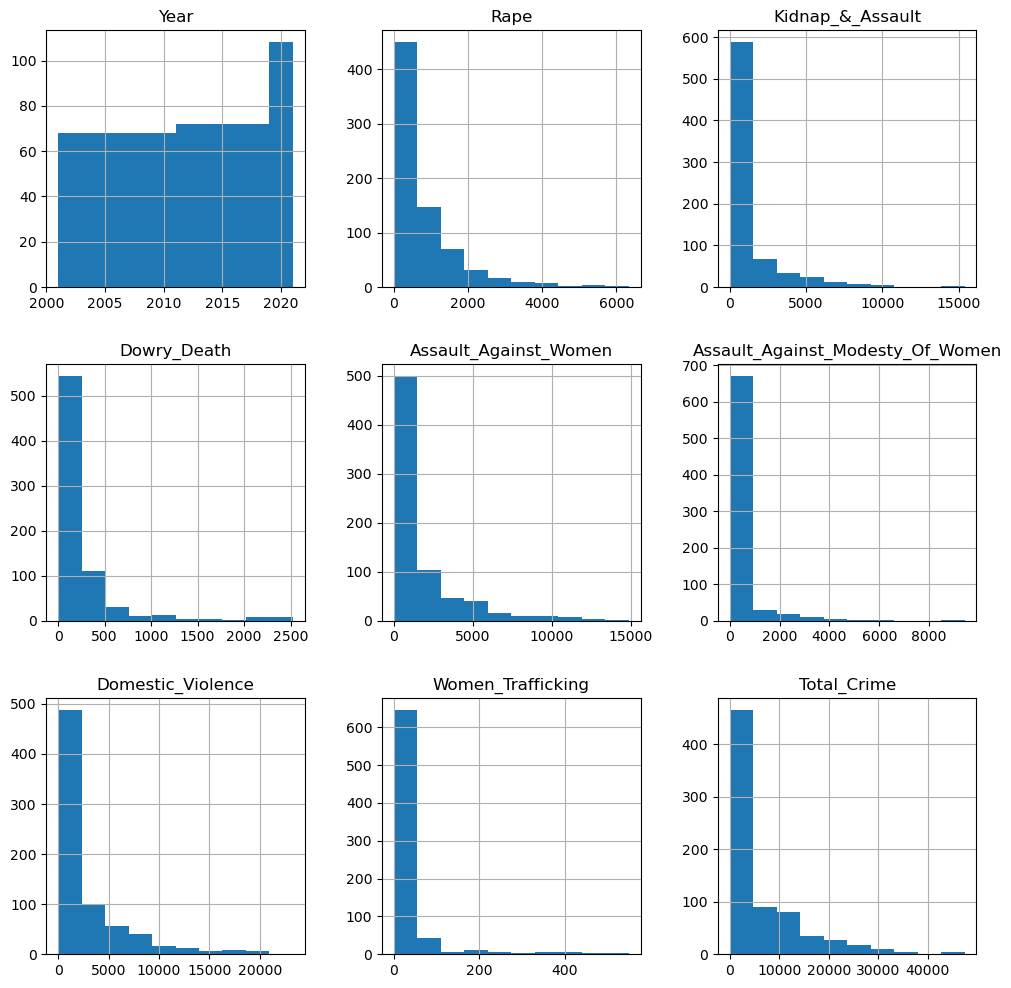

```python
datanum.hist(figsize=(12,12))
```

**The histograms show that most crime categories, including Rape, Dowry Death, and Domestic Violence, are highly right-skewed**

**Analysing the target variable**

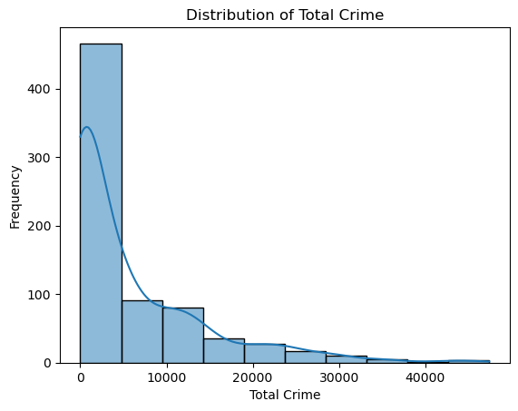

```python
sns.histplot(datanum["Total_Crime"], bins=10, kde=True)
plt.title("Distribution of Total Crime")
plt.xlabel("Total Crime")
plt.ylabel("Frequency")
plt.show()
```

**Total Crime is highly right-skewed**

## VI. Analyzing trends

**Analyzing the year-wise trend in Total_Crime**

```python
datanum_grouped = datanum.groupby('Year')['Total_Crime'].sum().reset_index()
datanum_grouped
```

|  | Year | Total_Crime |
| --- | --- | --- |
| 0 | 2001 | 112843 |
| 1 | 2002 | 113002 |
| 2 | 2003 | 112785 |
| 3 | 2004 | 122390 |
| 4 | 2005 | 121632 |
| 5 | 2006 | 131017 |
| 6 | 2007 | 150057 |
| 7 | 2008 | 161756 |
| 8 | 2009 | 169689 |
| 9 | 2010 | 178869 |
| 10 | 2011 | 154323 |
| 11 | 2012 | 210102 |
| 12 | 2013 | 264737 |
| 13 | 2014 | 296481 |
| 14 | 2015 | 289201 |
| 15 | 2016 | 296822 |
| 16 | 2017 | 273338 |
| 17 | 2018 | 280737 |
| 18 | 2019 | 301684 |
| 19 | 2020 | 274140 |
| 20 | 2021 | 316415 |

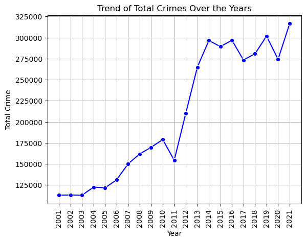

```python
sns.lineplot(x=datanum_grouped['Year'], y=datanum_grouped['Total_Crime'], marker="o", color="blue")
plt.title("Trend of Total Crimes Over the Years")
plt.xlabel("Year")
plt.ylabel("Total Crime")
plt.grid(True)
plt.xticks(ticks=datanum_grouped['Year'], rotation=90)
plt.show()
```

Gradual Increase (2005-2010): Starting in 2005, there is a noticeable upward trend in crime rates, increasing steadily through 2010. This growth could suggest increasing crime activities or improved reporting mechanisms during this period.

Fluctuating Plateau (2016-2021): After 2015, the crime rate enters a fluctuating plateau, with minor ups and downs between 275,000 and 325,000. A notable spike is visible in 2021, marking a new peak.

**Analyzing year-wise trend for each crime category**

```python
crime=datanum[['Kidnap_&_Assault','Dowry_Death','Assault_Against_Women',
                          'Assault_Against_Modesty_Of_Women','Domestic_Violence','Women_Trafficking']]
```

```python
crime
```

|  | Kidnap_&_Assault | Dowry_Death | Assault_Against_Women | Assault_Against_Modesty_Of_Women | Domestic_Violence | Women_Trafficking |
| --- | --- | --- | --- | --- | --- | --- |
| 0 | 765 | 420 | 3544 | 2271 | 5791 | 7 |
| 1 | 55 | 0 | 78 | 3 | 11 | 0 |
| 2 | 1070 | 59 | 850 | 4 | 1248 | 0 |
| 3 | 518 | 859 | 562 | 21 | 1558 | 83 |
| 4 | 171 | 70 | 1763 | 161 | 840 | 0 |
| ... | ... | ... | ... | ... | ... | ... |
| 731 | 4083 | 141 | 2068 | 417 | 4731 | 4 |
| 732 | 904 | 16 | 1851 | 10 | 501 | 1 |
| 733 | 1 | 0 | 5 | 1 | 9 | 0 |
| 734 | 0 | 0 | 1 | 1 | 3 | 0 |
| 735 | 0 | 2 | 31 | 3 | 12 | 0 |

736 rows × 6 columns

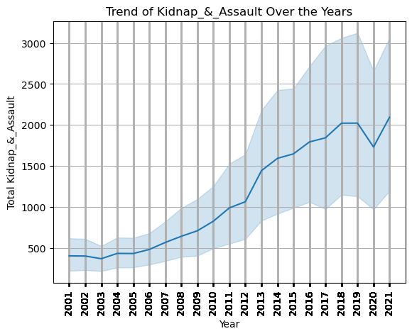

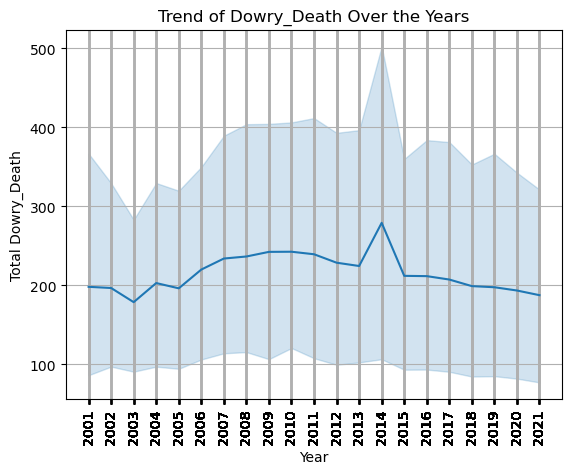

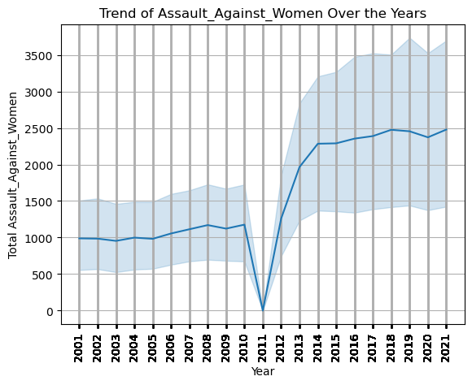

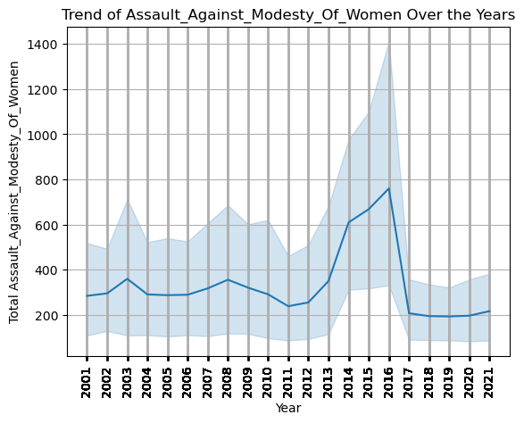

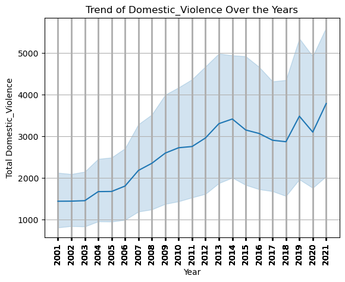

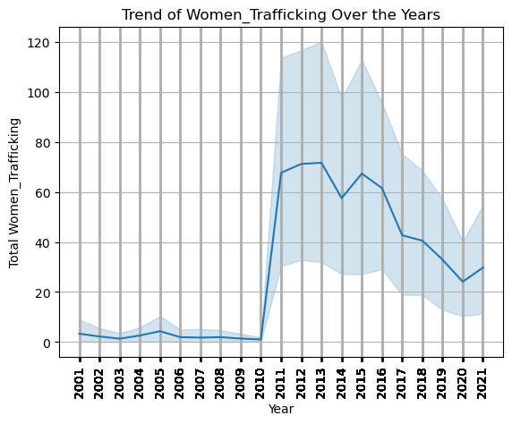

```python
# Loop through each crime category
for i in crime.columns:
    # Create the line plot for the current crime category
    sns.lineplot(x=datanum['Year'], y=datanum[i])

    plt.title(f"Trend of {i} Over the Years")
    plt.xlabel("Year")
    plt.ylabel(f"Total {i}")

    plt.grid(True)
    plt.xticks(datanum['Year'],rotation=90)
    plt.show()
```

**CHECKING SKEWNESS OF EACH COLUMN**

```python
yearly_data = datanum.groupby('Year').sum().reset_index()
```

```python
yearly_data
```

|  | Year | Rape | Kidnap_&_Assault | Dowry_Death | Assault_Against_Women | Assault_Against_Modesty_Of_Women | Domestic_Violence | Women_Trafficking | Total_Crime |
| --- | --- | --- | --- | --- | --- | --- | --- | --- | --- |
| 0 | 2001 | 15694 | 13681 | 6738 | 33622 | 9656 | 49032 | 114 | 112843 |
| 1 | 2002 | 15970 | 13613 | 6687 | 33497 | 10027 | 49102 | 76 | 113002 |
| 2 | 2003 | 15357 | 12499 | 6078 | 32450 | 12220 | 49492 | 46 | 112785 |
| 3 | 2004 | 17682 | 14697 | 6900 | 33966 | 9871 | 56867 | 89 | 122390 |
| 4 | 2005 | 17701 | 14644 | 6673 | 33413 | 9759 | 56995 | 148 | 121632 |
| 5 | 2006 | 18725 | 16348 | 7481 | 35899 | 9822 | 61400 | 67 | 131017 |
| 6 | 2007 | 20139 | 19249 | 7955 | 37866 | 10783 | 74143 | 61 | 150057 |
| 7 | 2008 | 21001 | 21803 | 8043 | 39802 | 12084 | 79957 | 67 | 161756 |
| 8 | 2009 | 20928 | 24086 | 8242 | 38159 | 10891 | 88263 | 48 | 169689 |
| 9 | 2010 | 21665 | 28055 | 8248 | 40012 | 9881 | 92637 | 36 | 178869 |
| 10 | 2011 | 24206 | 35565 | 8618 | 0 | 8570 | 99135 | 2435 | 154323 |
| 11 | 2012 | 24923 | 38262 | 8233 | 45344 | 9173 | 106527 | 2563 | 210102 |
| 12 | 2013 | 33707 | 51881 | 8083 | 70739 | 12589 | 118866 | 2579 | 264737 |
| 13 | 2014 | 36735 | 57311 | 10050 | 82235 | 21938 | 122877 | 2070 | 296481 |
| 14 | 2015 | 34651 | 59277 | 7634 | 82422 | 24041 | 113403 | 2424 | 289201 |
| 15 | 2016 | 38947 | 64519 | 7621 | 84746 | 27344 | 110378 | 2214 | 296822 |
| 16 | 2017 | 32559 | 66333 | 7466 | 86001 | 7451 | 104551 | 1536 | 273338 |
| 17 | 2018 | 33356 | 72751 | 7166 | 89097 | 6992 | 103272 | 1459 | 280737 |
| 18 | 2019 | 32033 | 72780 | 7115 | 88367 | 6939 | 125298 | 1185 | 301684 |
| 19 | 2020 | 28046 | 62300 | 6966 | 85392 | 7065 | 111549 | 868 | 274140 |
| 20 | 2021 | 31677 | 75369 | 6753 | 89200 | 7788 | 136234 | 1071 | 316415 |

```python
yearly_data.skew()
```

```
Year                                0.000000
Rape                                0.235891
Kidnap_&_Assault                    0.237559
Dowry_Death                         0.926611
Assault_Against_Women              -0.030358
Assault_Against_Modesty_Of_Women    1.923879
Domestic_Violence                  -0.261344
Women_Trafficking                   0.442471
Total_Crime                         0.112841
dtype: float64
```

## VII.Applying algorithms

```python
from sklearn.model_selection import train_test_split
from sklearn.linear_model import LinearRegression
from sklearn.ensemble import RandomForestRegressor
from sklearn.ensemble import GradientBoostingRegressor
from sklearn.tree import DecisionTreeRegressor
from xgboost import XGBRegressor
from sklearn.metrics import mean_squared_error, r2_score
```

## LINEAR REGRESSION

```python
# Prepare data for regression
x = yearly_data[['Year']]
y = yearly_data['Total_Crime']
```

```python
x_train, x_test, y_train, y_test = train_test_split(x, y, test_size=0.2, random_state=42)
```

```python
model = LinearRegression()
model.fit(x_train, y_train)
```

```
LinearRegression()
```

```python
print("Intercept:", model.intercept_)
print("Coefficients:", model.coef_)
```

```
Intercept: -24333702.225447815
Coefficients: [12201.27893762]
```

```python
# Predictions
y_pred = model.predict(x_test)
```

```python
mse = mean_squared_error(y_test, y_pred)
r2 = r2_score(y_test, y_pred)
print("Mean Squared Error:", mse)
print("R-squared Score (R²):", r2)
```

```
Mean Squared Error: 522601123.67650616
R-squared Score (R²): 0.9179124013542402
```

## Random Forest Regressor

```python
modelrfr = RandomForestRegressor(n_estimators=100, random_state=42)
```

```python
modelrfr.fit(x_train, y_train)
```

```
RandomForestRegressor(random_state=42)
```

```python
y_predrfr = model.predict(x_test)
```

```python
mse = mean_squared_error(y_test, y_predrfr)
r2 = r2_score(y_test, y_predrfr)
```

```python
print("Model Evaluation:")
print("Mean Squared Error (MSE):", mse)
print("R-squared Score (R²):", r2)
```

```
Model Evaluation:
Mean Squared Error (MSE): 522601123.67650616
R-squared Score (R²): 0.9179124013542402
```

## Decision Tree Regressor

```python
modelDTR = DecisionTreeRegressor(random_state=42)
```

```python
# Train the model
modelDTR.fit(x_train, y_train)
```

```
DecisionTreeRegressor(random_state=42)
```

```python
# Predict on the test set
y_predDTR = modelDTR.predict(x_test)
```

```python
# Evaluate the model
mse = mean_squared_error(y_test, y_predDTR)  # Mean Squared Error
r2 = r2_score(y_test, y_predDTR)  # R-squared Score
```

```python
print("Model Evaluation:")
print("Mean Squared Error (MSE):", mse)
print("R-squared Score (R²):", r2)
```

```
Model Evaluation:
Mean Squared Error (MSE): 35161556.8
R-squared Score (R²): 0.9944769966393239
```

## Gradient Boosting Regressor

```python
modelgbr = GradientBoostingRegressor(n_estimators=100,max_depth=3,learning_rate=0.1,random_state=42)
```

```python
# Train the model
modelgbr.fit(x_train, y_train)
```

```
GradientBoostingRegressor(random_state=42)
```

```python
y_predgbr = modelgbr.predict(x_test)
```

```python
mse = mean_squared_error(y_test, y_predgbr)
r2 = r2_score(y_test, y_predgbr)
```

```python
print("Model Evaluation:")
print("Mean Squared Error (MSE):", mse)
print("R-squared Score (R²):", r2)
```

```
Model Evaluation:
Mean Squared Error (MSE): 34848176.3680774
R-squared Score (R²): 0.9945262208869453
```

## XGB Regressor

```python
modelxgb = XGBRegressor(n_estimators=100, random_state=42)
```

```python
modelxgb.fit(x_train, y_train)
```

```
XGBRegressor(base_score=None, booster=None, callbacks=None,
             colsample_bylevel=None, colsample_bynode=None,
             colsample_bytree=None, device=None, early_stopping_rounds=None,
             enable_categorical=False, eval_metric=None, feature_types=None,
             gamma=None, grow_policy=None, importance_type=None,
             interaction_constraints=None, learning_rate=None, max_bin=None,
             max_cat_threshold=None, max_cat_to_onehot=None,
             max_delta_step=None, max_depth=None, max_leaves=None,
             min_child_weight=None, missing=nan, monotone_constraints=None,
             multi_strategy=None, n_estimators=100, n_jobs=None,
             num_parallel_tree=None, random_state=42, ...)
```

```python
y_predxgb = modelxgb.predict(x_test)
```

```python
mse = mean_squared_error(y_test, y_predxgb)
r2 = r2_score(y_test, y_predxgb)
```

```python
print("Model Evaluation:")
print("Mean Squared Error (MSE):", mse)
print("R-squared Score (R²):", r2)
```

```
Model Evaluation:
Mean Squared Error (MSE): 35161178.062524416
R-squared Score (R²): 0.9944770336151123
```